# CM20261021_linear_disthopping_insert

2026-04-10

#Goal Visualize the relationship between linear distance and number of integrations, for the two launch sites (Nanog_1 and Sox2_-116kb) for which we have many different cargo.

# Setup

##Libraries Load the libraries and set the parameters.

```r
# Load dependencies
library(GenomicRanges)
library(rtracklayer)
library(gtools)
library(tidyverse)
```

```r
library(dplyr)
library(ggplot2)
library(ggh4x)
library(stringr)
library(readr)
library(knitr)
library(cowplot)
library(ggpubr)
library(BSgenome.Mmusculus.UCSC.mm10)
library(Biostrings)
library(ggseqlogo)
library(ShortRead)
library(GENOVA)
library(GGally)
library(ggbeeswarm)
library(scales)
split_string <- function(vect,sep,N1,N2=N1){
  library(stringr)
  sapply(vect, function(X){
    paste(str_split(X,sep)[[1]][N1:N2],collapse = sep)
  },USE.NAMES = F)
}
```

## Paths & parameters

```r
#datatag
datetag = paste0("CM",format(Sys.time(), '%Y%m%d'))

# Prepare output
output_dir <- paste0("/home/c.moene/projects/hopping_technology/05_hopping_distribution_single_LPs/analysis_",datetag)
dir.create(output_dir, showWarnings = FALSE)
```

```r
library(knitr)
opts_chunk$set(cache = T,
               message = F, warning = F,
               dev=c('png', 'pdf'),
               dpi = 300,
               fig.path = paste0(file.path(output_dir), "/distance/"))
pdf.options(useDingbats = FALSE)
```

```r
#cutoff to call an integration local
distance_local_hop = 2E6
```

# Load data

```r
all_ints_comb = read_tsv( "/home/c.moene/projects/hopping_technology/SB_transposition_manuscript/Figure5_integration_locations_cargo/CM20260104_collected_mapped_ints_all.tsv")

all_ints_comb = all_ints_comb %>%
  mutate(type = replace_na(type,'pool'))
```

## all inserts

Filter for WT genomic background

```r
table(all_ints_comb$LP, all_ints_comb$insert, useNA = 'ifany')
```

```
##
##           1xCTCF_fw_Sox2P 1xCTCF_rv 3xCTCF_fw 3xCTCF_fw_Sox2P 3xCTCF_rv_Sox2P
##   -116 kb            2181     12247      1935             961             933
##   -161 kb               0         0         0               0               0
##   -39 kb               85         0         0             367              69
##   +715 kb               0         0         0               0               0
##   F108                  0         0         0               0               0
##   Fzd5                  0         0         0               0               0
##   in SCR                0         0         0               0               0
##   N1                    0         0         0               0               0
##   N2                    0         0         0               0               0
##   N31                   0         0         0               0               0
##   N37                   0         0         0               0               0
##   T137                  0         0         0               0               0
##   T201                  0         0         0               0               0
##   T3                    0         0         0               0               0
##   T48                   0         0         0               0               0
##   Tdgf1                 0         0         0               0               0
##
##           minimal insert NanogL03 NanogS02 NanogS08 NanogS10 pLE005 pLE006
##   -116 kb           8117        0        0        0        0      0      0
##   -161 kb              0        0        0        0        0      0      0
##   -39 kb               0        0        0        0        0      0      0
##   +715 kb              0        0        0        0        0      0      0
##   F108                60        0        0        0        0      0      0
##   Fzd5                74        0        0        0        0      0      0
##   in SCR               0        0        0        0        0      0      0
##   N1                5707     4259     5651      842     1882   2032   3063
##   N2                   0        0        0        0        0      0      0
##   N31                 63        0        0        0        0      0      0
##   N37                 61        0        0        0        0      0      0
##   T137               132        0        0        0        0      0      0
##   T201               427        0        0        0        0      0      0
##   T3                 140        0        0        0        0      0      0
##   T48                199        0        0        0        0      0      0
##   Tdgf1              200        0        0        0        0      0      0
##
##           pLE007 pLE009 pLE011 pMV001 Sox2P Sox2P_CDS
##   -116 kb      0      0      0      0  8001         0
##   -161 kb      0      0      0      0  7056      4176
##   -39 kb       0      0      0      0   437         0
##   +715 kb      0      0      0      0  1265         0
##   F108         0      0      0      0     0         0
##   Fzd5         0      0      0      0     0         0
##   in SCR       0      0      0      0  3459         0
##   N1         799   3323    788     41     0         0
##   N2           0      0      0    830     0         0
##   N31          0      0      0      0     0         0
##   N37          0      0      0      0     0         0
##   T137         0      0      0      0     0         0
##   T201         0      0      0      0     0         0
##   T3           0      0      0      0     0         0
##   T48          0      0      0      0     0         0
##   Tdgf1        0      0      0      0     0         0
```

```r
all_local_ints = all_ints_comb %>%
  dplyr::filter(type == "pool" & genotype == "WT") %>%
  mutate(hopped = start != LP_coordinate,
         dist_to_LP = case_when(chr == LP_chr ~ start - LP_coordinate,
                                .default = NA),
         local_hop = abs(dist_to_LP) < distance_local_hop & !is.na(dist_to_LP) & hopped) %>% #dont include unhopped ints
  dplyr::filter(local_hop)

table(all_local_ints$LP, all_local_ints$insert, useNA = 'ifany')
```

```
##
##           1xCTCF_fw_Sox2P 1xCTCF_rv 3xCTCF_fw 3xCTCF_fw_Sox2P 3xCTCF_rv_Sox2P
##   -116 kb             643      8213      1329             270             488
##   -161 kb               0         0         0               0               0
##   -39 kb               56         0         0              89              24
##   +715 kb               0         0         0               0               0
##   F108                  0         0         0               0               0
##   Fzd5                  0         0         0               0               0
##   in SCR                0         0         0               0               0
##   N1                    0         0         0               0               0
##   N2                    0         0         0               0               0
##   N31                   0         0         0               0               0
##   N37                   0         0         0               0               0
##   T137                  0         0         0               0               0
##   T201                  0         0         0               0               0
##   T3                    0         0         0               0               0
##   T48                   0         0         0               0               0
##   Tdgf1                 0         0         0               0               0
##
##           minimal insert NanogL03 NanogS02 NanogS08 NanogS10 pLE005 pLE006
##   -116 kb           4327        0        0        0        0      0      0
##   -161 kb              0        0        0        0        0      0      0
##   -39 kb               0        0        0        0        0      0      0
##   +715 kb              0        0        0        0        0      0      0
##   F108                31        0        0        0        0      0      0
##   Fzd5                36        0        0        0        0      0      0
##   in SCR               0        0        0        0        0      0      0
##   N1                2404      725     1257      169      280    631    893
##   N2                   0        0        0        0        0      0      0
##   N31                 32        0        0        0        0      0      0
##   N37                 19        0        0        0        0      0      0
##   T137                51        0        0        0        0      0      0
##   T201                83        0        0        0        0      0      0
##   T3                  40        0        0        0        0      0      0
##   T48                 68        0        0        0        0      0      0
##   Tdgf1               93        0        0        0        0      0      0
##
##           pLE007 pLE009 pLE011 pMV001 Sox2P Sox2P_CDS
##   -116 kb      0      0      0      0  1118         0
##   -161 kb      0      0      0      0   617       573
##   -39 kb       0      0      0      0   155         0
##   +715 kb      0      0      0      0   522         0
##   F108         0      0      0      0     0         0
##   Fzd5         0      0      0      0     0         0
##   in SCR       0      0      0      0   147         0
##   N1         292    845    262     11     0         0
##   N2           0      0      0    211     0         0
##   N31          0      0      0      0     0         0
##   N37          0      0      0      0     0         0
##   T137         0      0      0      0     0         0
##   T201         0      0      0      0     0         0
##   T3           0      0      0      0     0         0
##   T48          0      0      0      0     0         0
##   Tdgf1        0      0      0      0     0         0
```

There is a contamination with some clones

Mathias dealt with this before for the CTCF paper, get filtered version from him. filtered version E2401 from CTCF paper

```r
tib_E2401_curated_strict = readRDS("/home/c.moene/projects/hopping_technology/SB_transposition_manuscript/Figure5_integration_locations_cargo/E2401_curated_strict.rds")

tib_E2401_curated_strict_ctrls = tib_E2401_curated_strict %>%
  dplyr::mutate(insert = case_when(insert == "CBS1x_Fw_Sox2P" ~ '1xCTCF_fw_Sox2P',
                                   insert == "CBS3x_Fw_Sox2P" ~ '3xCTCF_fw_Sox2P',
                                   insert == "CBS3x_Rv_Sox2P" ~ '3xCTCF_rv_Sox2P',
                                     .default = insert)) %>%
  filter(sample_type == "control pool") %>%
  mutate(LP = "-116 kb",
         LP_coordinate = 34643961,
         LP_chr = "chr3",
         genotype = "WT",
         hopped = start != LP_coordinate,
         dist_to_LP = case_when(chr == LP_chr ~ start - LP_coordinate,
                                .default = NA),
         local_hop = abs(dist_to_LP) < distance_local_hop & !is.na(dist_to_LP) & hopped) %>%
  filter(experiment == "E2401")
```

#filtered version dataset add int he corretly filtered version of E2401 and remove any launch pad contaminations, as we also did in the Science paper.

```r
all_local_ints_filt = all_local_ints %>%
  filter(experiment != "E2401") %>%
  bind_rows(filter(tib_E2401_curated_strict_ctrls, local_hop)) %>%
  #standard filtering from the Sox2 paper
    filter(!(start >= 34721183 & start <= 34721192)) %>% #remove contamination from LP8
  filter(! start %in% c(25018987, 35232946) ) %>% #remove contamination clone C1
  filter(landing_pad  == "C9" | start != 34598479) %>% #remove contamination from LP C9
  filter(landing_pad  == "23" | start != 34643961) %>% #remove contamination from LP 23
  filter(landing_pad  == "C10" | start != 35478413)  #remove contamination from LP C10
```

#plot fraction in regions Fraction in regions

```r
insert_category_cols_2 <- c(
  "promoter" = "#1B9E77",
  "TF reporter" = "#a6761d", #added a new color for the TF reporters in this figure
  "CTCF" = "#7570B3",
  "CTCF+promoter" = "#E7298A",
  "minimal insert" = "#666666",
  "other" = "grey80"
)

colscale_insert_cat_2 = scale_color_manual(values = insert_category_cols_2, aesthetics = 'col')
```

## Sox2

For the Sox2 launch site, we plot per biorep

```r
plot_fract_Sox2 = filter(all_local_ints_filt, LP %in% c("-116 kb", "-161 kb", "N1")) %>%
  mutate(insert_sample = paste0(insert, "_", experiment)) %>%
  group_by(insert_sample) %>%
  filter(LP == c("-116 kb")) %>%
    filter(insert %in% c('minimal insert', 'Sox2P'))%>%
  mutate(insert_group = case_when(grepl('Sox2P', insert)~ "promoter",
                                  insert == 'minimal insert' ~ 'minimal insert'))%>%
  uncount(read_count) %>%
  mutate(region_ints = case_when(abs(dist_to_LP) < 10E3 ~ "<10kb",
                                 abs(dist_to_LP) < 100E3 ~ "10kb-100kb",
                                 abs(dist_to_LP) < 500E3 ~ "100kb-500kb",
                                 abs(dist_to_LP) < 2E6 ~ "500kb-2Mb",
                                 .default = 'problem'
                                 )
  )%>%
  mutate(region_ints = factor(region_ints, levels = c("<10kb", "10kb-100kb", "100kb-500kb", "500kb-2Mb")))%>%
  group_by(insert_sample,insert,insert_group, region_ints)%>%
  summarize(N = n())%>%
  mutate(fract_ints = N/sum(N))%>%
  ggplot(aes(x = region_ints, y = fract_ints, col = insert_group)) +
  scale_y_continuous(limits = c(0, NA), expand = expansion(mult = c(0, 0.05)))+
  geom_boxplot()+
  geom_point(position = position_jitterdodge(jitter.width = 0.3, jitter.height = 0))+
  theme_bw()+
  xlab('region of integration')+
  ylab('fraction of SB reads') +
  ggtitle('Sox2 locus, -116kb, per replicate')+
  theme(legend.position = 'bottom',
        aspect.ratio = 1) +
  colscale_insert_cat_2


filter(all_local_ints_filt, LP %in% c("-116 kb", "-161 kb", "N1")) %>%
  mutate(insert_sample = paste0(insert, "_", experiment)) %>%
  group_by(insert_sample) %>%
  filter(LP == c("-116 kb")) %>%
    filter(insert %in% c('minimal insert', 'Sox2P'))%>%
  mutate(insert_group = case_when(grepl('Sox2P', insert)~ "promoter",
                                  insert == 'minimal insert' ~ 'minimal insert'))%>%
  uncount(read_count) %>%
  mutate(region_ints = case_when(abs(dist_to_LP) < 10E3 ~ "<10kb",
                                 abs(dist_to_LP) < 100E3 ~ "10kb-100kb",
                                 abs(dist_to_LP) < 500E3 ~ "100kb-500kb",
                                 abs(dist_to_LP) < 2E6 ~ "500kb-2Mb",
                                 .default = 'problem'
                                 )
  )%>%
  mutate(region_ints = factor(region_ints, levels = c("<10kb", "10kb-100kb", "100kb-500kb", "500kb-2Mb")))%>%
  group_by(insert_sample,insert,insert_group, region_ints)%>%
  summarize(N = n())%>%
  mutate(fract_ints = N/sum(N)) %>%
  filter(region_ints == "<10kb") %>%
  group_by(insert) %>%
  summarise(mean(fract_ints))
```

```
## # A tibble: 2 × 2
##   insert         `mean(fract_ints)`
##   <chr>                       <dbl>
## 1 Sox2P                      0.164
## 2 minimal insert             0.0554
```

## Nanog

For the Nanog locus, we plot per unique insert (combining bioreps)

```r
plot_fract_Nanog = filter(all_local_ints_filt, LP %in% c("-116 kb", "-161 kb", "N1")) %>%
  # mutate(insert_sample = paste0(insert, "_", experiment)) %>%
  group_by(insert) %>%
  filter(LP == c("N1") & ! insert %in% c("NanogS08", "NanogS10", "pMV001")) %>%
  mutate(insert_group = case_when(grepl('Nanog', insert)~ "promoter",
                                  grepl('pLE', insert) ~ "TF reporter",
                                  insert == 'minimal insert' ~ insert)) %>%
  uncount(read_count) %>%
  mutate(region_ints = case_when(abs(dist_to_LP) < 10E3 ~ "<10kb",
                                 abs(dist_to_LP) < 100E3 ~ "10kb-100kb",
                                 abs(dist_to_LP) < 500E3 ~ "100kb-500kb",
                                 abs(dist_to_LP) < 2E6 ~ "500kb-2Mb",
                                 .default = 'problem'
                                 )
  )%>%
  mutate(region_ints = factor(region_ints, levels = c("<10kb", "10kb-100kb", "100kb-500kb", "500kb-2Mb")))%>%
  group_by(insert,insert_group, region_ints)%>%
  summarize(N = n())%>%
  mutate(fract_ints = N/sum(N))%>%
  ggplot(aes(x = region_ints, y = fract_ints, col = insert_group)) +
  scale_y_continuous(limits = c(0, NA), expand = expansion(mult = c(0, 0.05)))+
  geom_boxplot(outlier.shape = NA)+
  geom_point(position = position_jitterdodge(jitter.width = 0.3, jitter.height = 0))+
  theme_bw()+
  xlab('region of integration')+
  ylab('fraction of SB reads') +
  ggtitle('Nanog locus, per unique insert')+
  theme(legend.position = 'bottom',
        aspect.ratio = 1) +
  colscale_insert_cat_2


filter(all_local_ints_filt, LP %in% c("-116 kb", "-161 kb", "N1")) %>%
  # mutate(insert_sample = paste0(insert, "_", experiment)) %>%
  group_by(insert) %>%
  filter(LP == c("N1") & ! insert %in% c("NanogS08", "NanogS10", "pMV001")) %>%
  mutate(insert_group = case_when(grepl('Nanog', insert)~ "promoter",
                                  grepl('pLE', insert) ~ "TF reporter",
                                  insert == 'minimal insert' ~ insert,
                                  insert == 'pMV001' ~ 'enhancer')) %>%
  uncount(read_count) %>%
  mutate(region_ints = case_when(abs(dist_to_LP) < 10E3 ~ "<10kb",
                                 abs(dist_to_LP) < 100E3 ~ "10kb-100kb",
                                 abs(dist_to_LP) < 500E3 ~ "100kb-500kb",
                                 abs(dist_to_LP) < 2E6 ~ "500kb-2Mb",
                                 .default = 'problem'
                                 )
  )%>%
  mutate(region_ints = factor(region_ints, levels = c("<10kb", "10kb-100kb", "100kb-500kb", "500kb-2Mb")))%>%
  group_by(insert, insert_group, region_ints)%>%
  summarize(N = n())%>%
  mutate(fract_ints = N/sum(N))%>%
  filter(region_ints == "<10kb") %>%
  group_by(insert) %>%
  summarise(mean(fract_ints))
```

```
## # A tibble: 8 × 2
##   insert         `mean(fract_ints)`
##   <chr>                       <dbl>
## 1 NanogL03                    0.436
## 2 NanogS02                    0.426
## 3 minimal insert              0.404
## 4 pLE005                      0.419
## 5 pLE006                      0.407
## 6 pLE007                      0.519
## 7 pLE009                      0.394
## 8 pLE011                      0.478
```

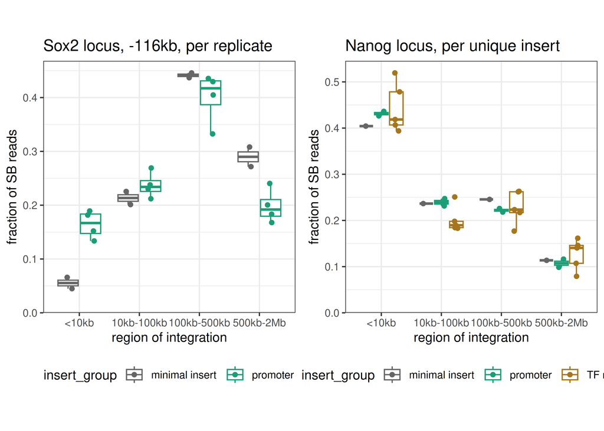

```r
cowplot::plot_grid(plot_fract_Sox2, plot_fract_Nanog, nrow = 1,
                   align = 'h', axis = 'tb')
```

## TF reporter expression

Compare <10kb fraction TF reporters to their expression

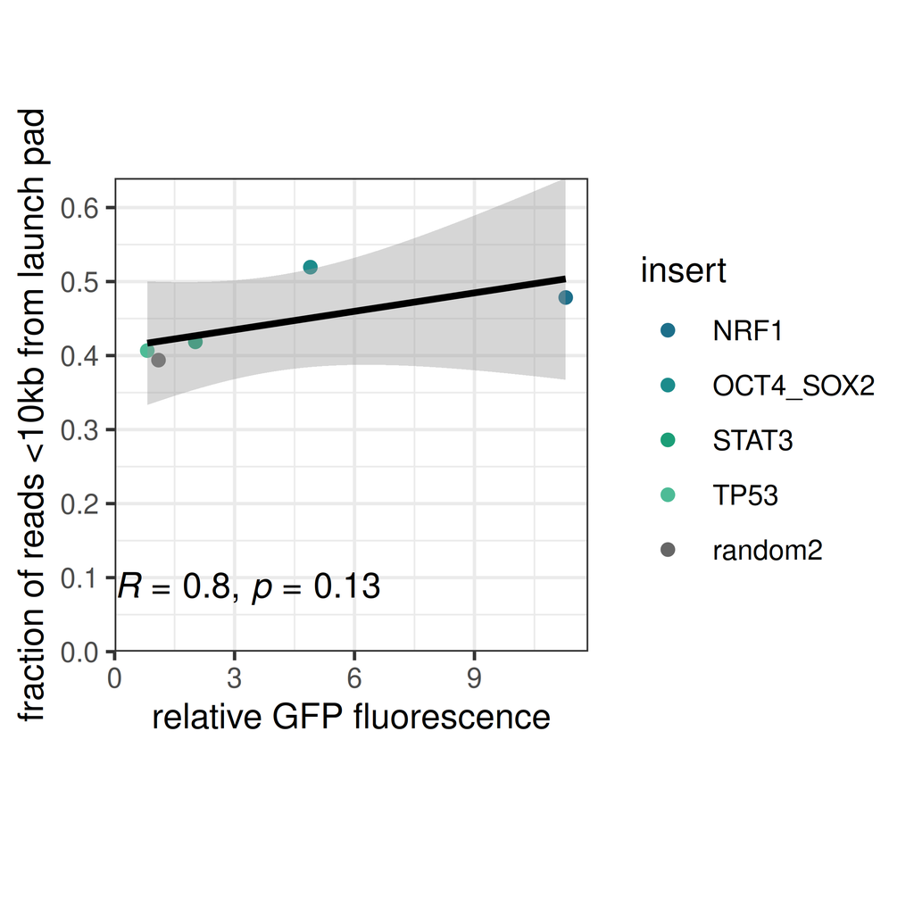

```r
tib_expr_TF = readRDS('/home/c.moene/projects/hopping_technology/SB_transposition_manuscript/Figure5_integration_locations_cargo/CM20260415_fluorescence_TF_reporters.rds')

tib_expr_TF_for_join = tib_expr_TF %>%
  filter(clone == '1' & insert != "WT" ) %>%
  mutate(insert_name_join = case_when(insert == "TP53" ~ 'tfr_p53',
                                      .default = paste0("tfr_", tolower(insert))))


promoter_cols <- c(
  "NRF1" = "#1D6F8A",
  "OCT4_SOX2" = "#1C8C8C",
  "STAT3" = "#1B9E77",
  "TP53" = "#4DBB96",
  "random2" = "grey40"
)

tib_for_plot_GFP_local =
  filter(all_local_ints_filt, LP %in% c("-116 kb", "-161 kb", "N1")) %>%
  mutate(insert_sample = paste0(insert, "_", experiment)) %>%
  group_by(insert_sample) %>%
  filter(LP == c("N1") & ! insert %in% c("NanogS08", "NanogS10", "pMV001")) %>%
  mutate(insert_group = case_when(grepl('Nanog', insert)~ "promoter",
                                  grepl('pLE', insert) ~ "TF reporter",
                                  insert == 'minimal insert' ~ insert,
                                  insert == 'pMV001' ~ 'enhancer')) %>%
  uncount(read_count) %>%
  mutate(region_ints = case_when(abs(dist_to_LP) < 10E3 ~ "<10kb",
                                 abs(dist_to_LP) < 100E3 ~ "10kb-100kb",
                                 abs(dist_to_LP) < 500E3 ~ "100kb-500kb",
                                 abs(dist_to_LP) < 2E6 ~ "500kb-2Mb",
                                 .default = 'problem'
  )
  )%>%
  mutate(region_ints = factor(region_ints, levels = c("<10kb", "10kb-100kb", "100kb-500kb", "500kb-2Mb")))%>%
  group_by(insert_sample, insert_group, insert_name, region_ints)%>%
  summarize(N = n())%>%
  mutate(fract_ints = N/sum(N))%>%
  filter(insert_group== "TF reporter") %>%
  mutate(insert_name_join = tolower(insert_name)) %>%
  left_join(tib_expr_TF_for_join) %>%

  #for plotting
  filter(region_ints == "<10kb") %>%
  mutate(insert = factor(insert, levels = names(promoter_cols))) #order nicely for legend


ggplot(tib_for_plot_GFP_local, aes(x = rel_GFP_cor, y = fract_ints)) +
  #plot data
  geom_point(aes( col = insert)) +
  stat_cor(label.y.npc = 'bottom', method = 'spearman') +
  geom_smooth(method = 'lm', col = 'black')+
  #layout
  scale_x_continuous(limits = c(0, NA), expand = expansion(mult = c(0,0.05)))+
  scale_y_continuous(limits = c(0,NA), expand = c(0,0), breaks = pretty_breaks(n=5)) +
  xlab('relative GFP fluorescence') +
  ylab('fraction of reads <10kb from launch pad')+
  theme_bw() +
  scale_color_manual(values = promoter_cols) +
  theme(aspect.ratio = 1)
```